# A Global Analysis on Inflation

[figure not shown]

[figure not shown]

[figure not shown]

[figure not shown]

[figure not shown]

[figure not shown]

[figure not shown]

[figure not shown]

[figure not shown]

[figure not shown]

[figure not shown]

[figure not shown]

[3 more figures not shown]

# Introduction

### Data Cleaning

- My first thought when I saw my data was that it had already been pre-processed and cleaned by the person who had collected the data, and therefore had no mistakes considering how easy it it to access world economic data.
- After closely reviewing the data I found many inconsistencies, particularly in Turkey and Indonesia’s GDP and Inflation. Because of this, I chose not to include Turkey or Indonesia in conducting analysis that involved these variables.
- This dataset measures economic growth as the percent change in GDP. Therefore, with these inconsistencies in these country’s GDP, I chose to ignore their data values altogether, creating a new variable called “filtered_data”.

### Data Organization

- To organize my data, I created a new variable called “Economic Classification” which aimed to label each country in my data set as either a “Developed” or “Developing” Economy. This way I could identify the differences between how inflation impacts countries based on how advanced their economy is, rather than pooling every country into the same category.

# Distributions of Inflation

### Overall

#### Interpretation

- For overall Inflation rates across all countries, the distribution was skewed to the right.
- The range was 26.2 percentage points, with an IQR of only 3.8 percentage points.
- There were 8 outliers, all positive, with the maximum value being 25% (Pakistan, 2024).

#### Charts

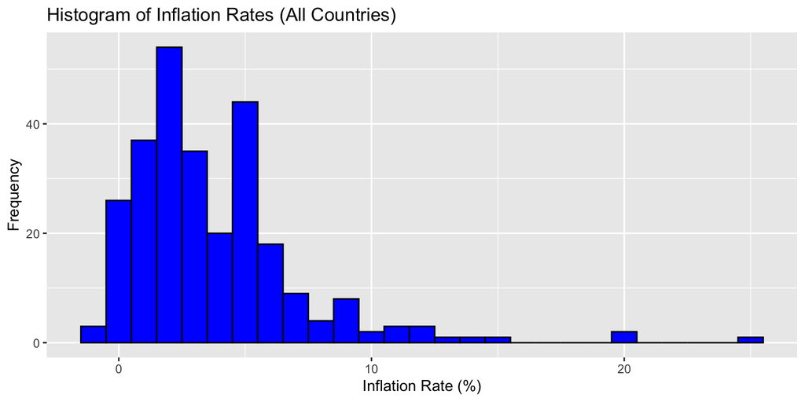

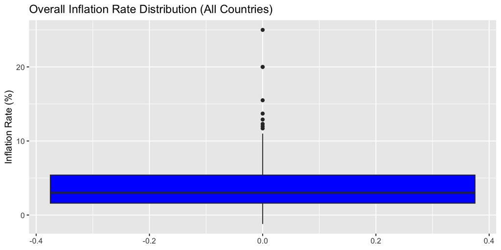

### Developed

#### Charts

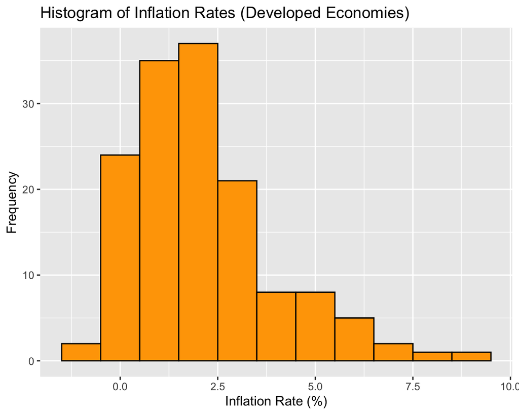

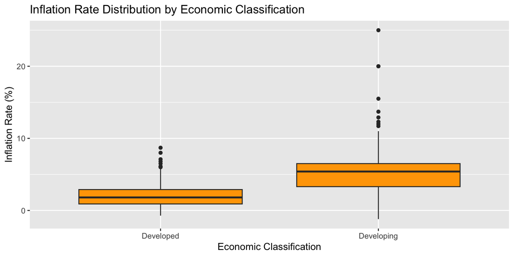

### Developing

#### Interpretation

- Inflation rates in developing economies saw much more volatile inflation rates over the years.
- The distribution is skewed to the right, with a minimum value of -1.2% and a maximum value of 25%, giving us a range of 26.2 percentage points.
- This range is far greater than the developed economies range of only 9.42 percent, showing much more instability and inconsistency.

#### Charts

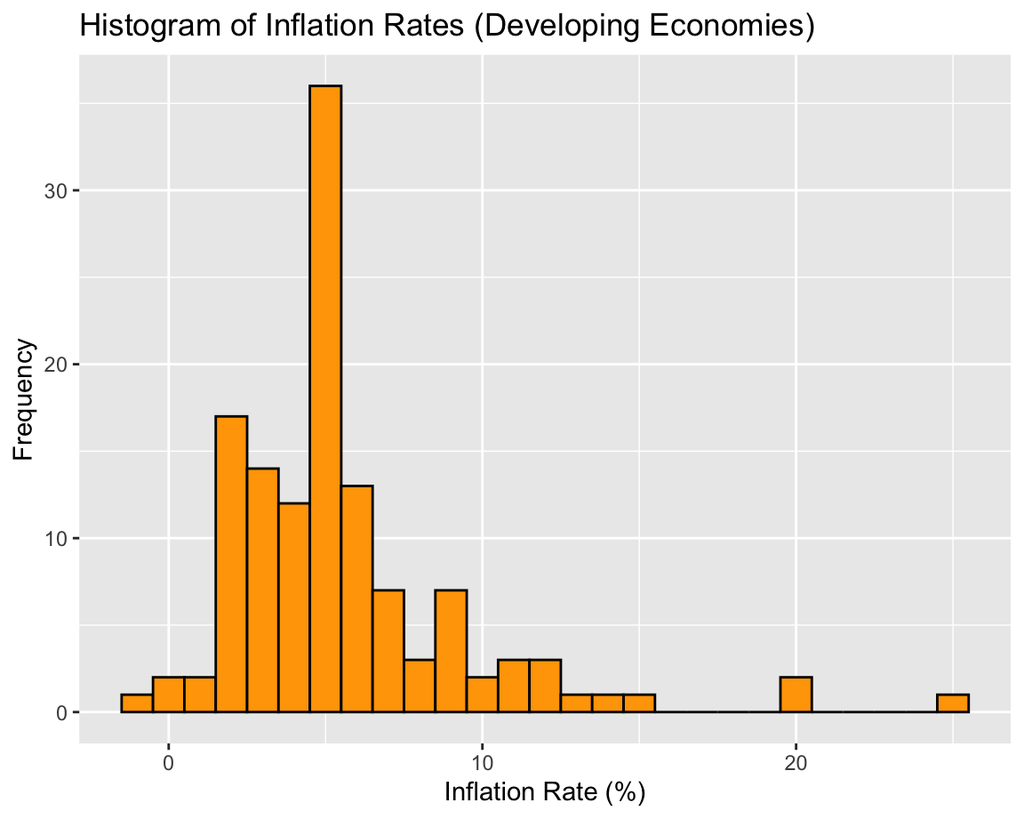

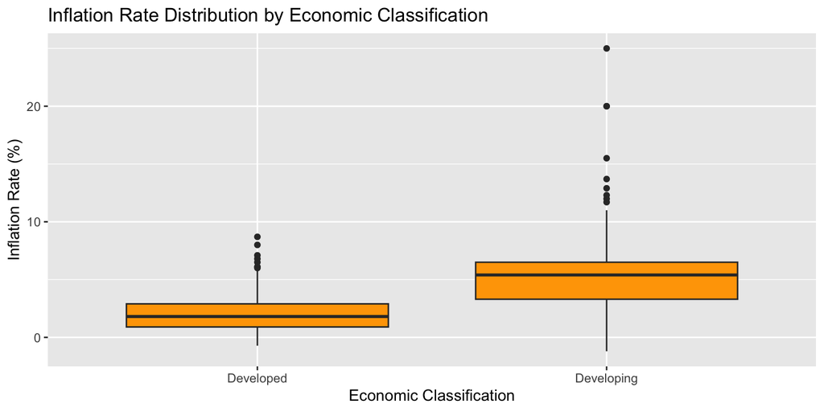

# Distributions of Economic Growth

### Overall

#### Interpretation

- For overall rates of economic growth across all countries in this data set, there is a relatively normal distribution despite the large amount of outliers on either side of the distribution.
- The range of the distribution is 24.5 percentage points and the IQR is only 3.2 percentage points.

#### Charts

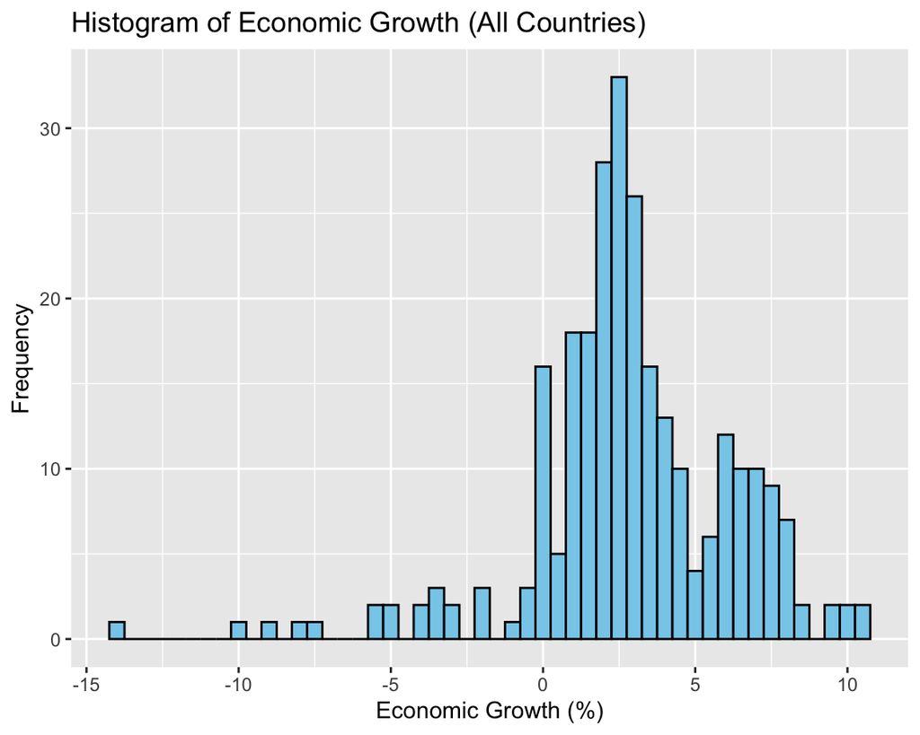

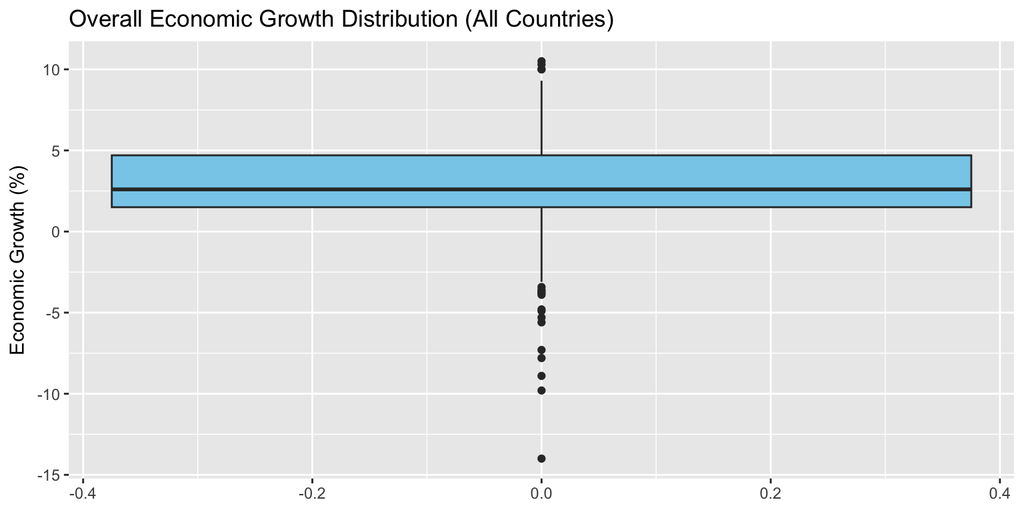

### Developed

#### Interpretation

- For developed economies, the distribution of economic growth is approximately normal with a slight left tail due to the negative outliers.
- The bulk of the data is within 0-5% and the median is 2.2%.
- An IQR of 1.6 shows a rather low - yet stable - rate of economic growth across developed economies over time.

#### Charts

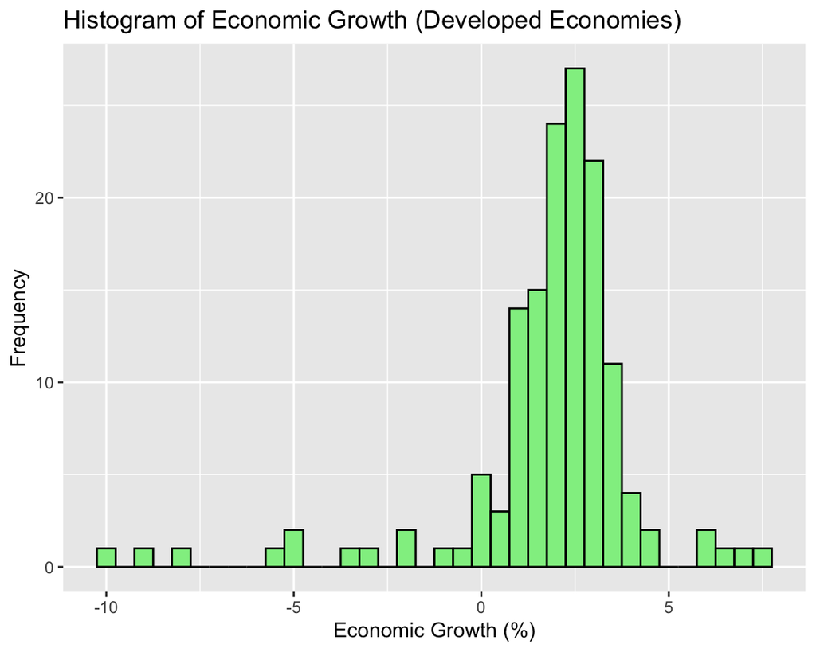

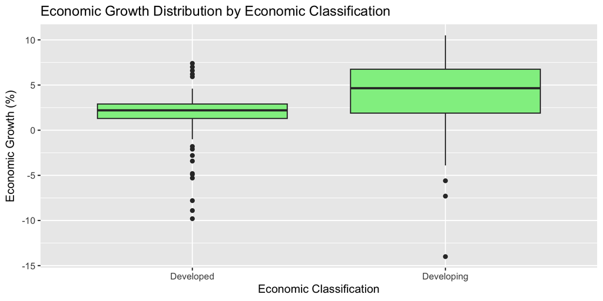

### Developing

#### Charts

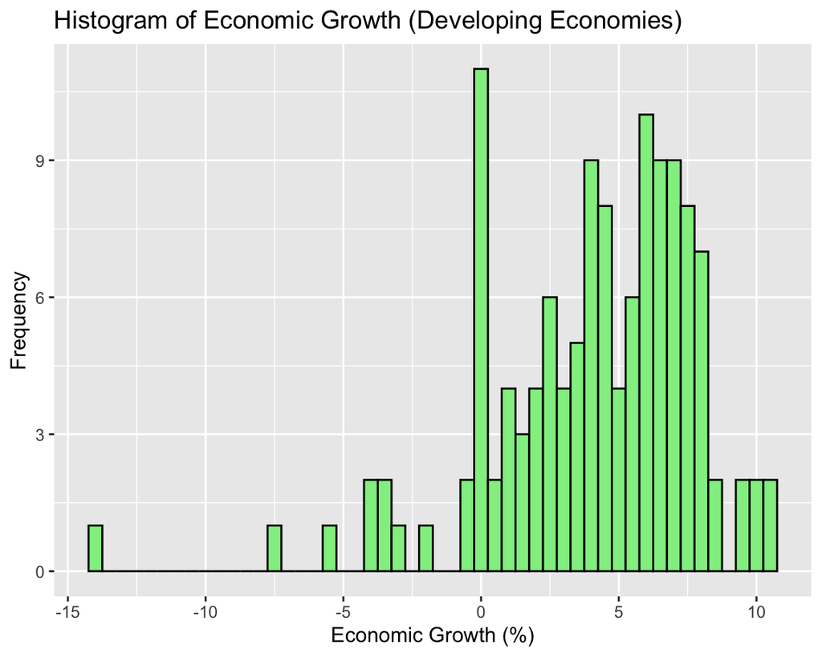

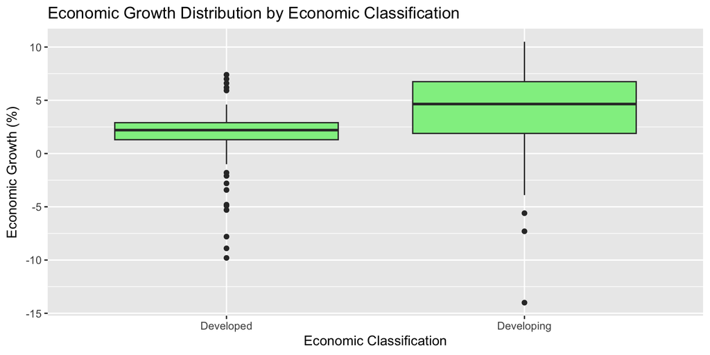

# Scatterplot Analysis

### Overall

#### Analysis

- After viewing the distributions of inflation rates and economic growth across different levels of economies, we can begin to investigate this projects 2 research questions:
  - How does inflation impact economic growth across different regions over time?
  - Are there noticeable differences in inflation trends between developed and developing countries?
- The scatterplot of inflation rate and economic growth across all countries suggests a very weak positive linear relationship between inflation and economic growth across all countries. While the trendline slopes upward slightly, a wide dispersion of points indicates that inflation alone does not necessarily explain variation in growth.

#### Graph

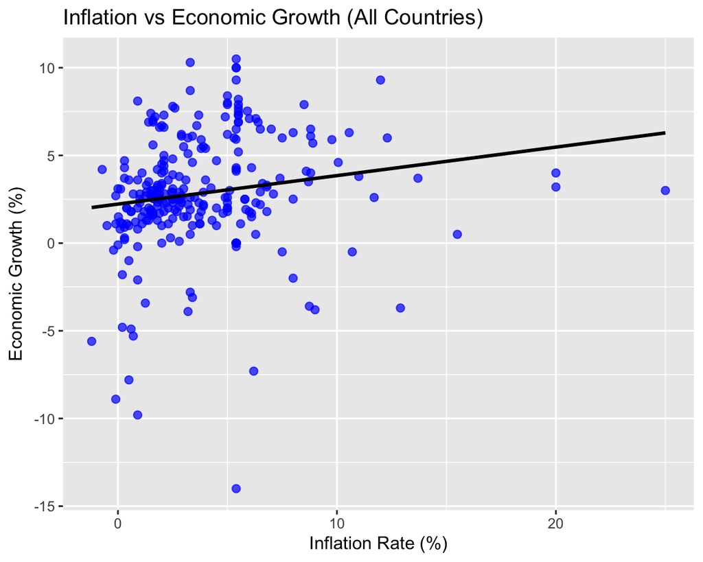

### Developed

#### Analysis

- In developed economies, the relationship between inflation and economic growth appears more consistent. The data shows a modest positive correlation, with countries experiencing moderate inflation often see stronger growth.
- While the relationship isn’t perfectly linear, the lack of an extreme spread in both inflation and growth suggest that moderate inflation may support low, but stable, economic growth

#### Graph

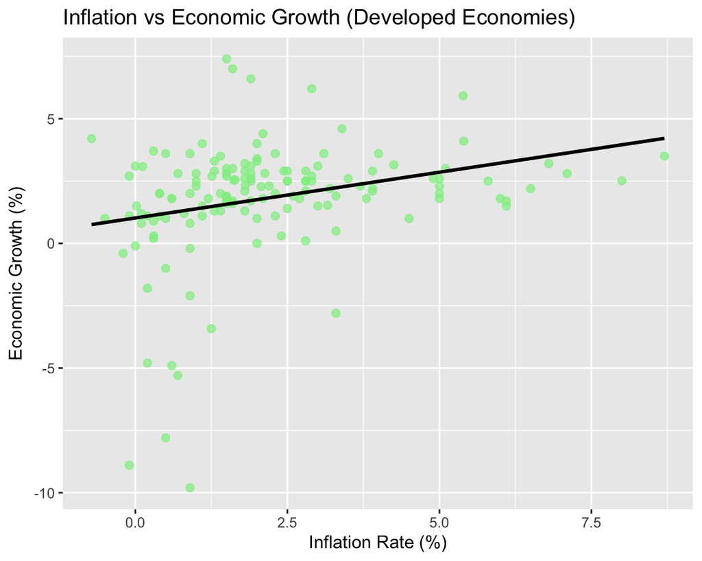

### Developing

#### Analysis

- For developing economies, the relationship between inflation and economic growth is slightly negative, meaning countries with higher inflation rates often see lower or unstable economic growth.
- While many countries with moderate inflation still experience healthy growth, the data becomes more dispersed as inflation rises. This suggests that in developing economies, high inflation may contribute to economic instability, harming growth.
- However, the relationship between inflation and growth for developing economies is weak, meaning economic growth is likely to be less prone to influence by inflation alone compared to more developed economies.

#### Graph

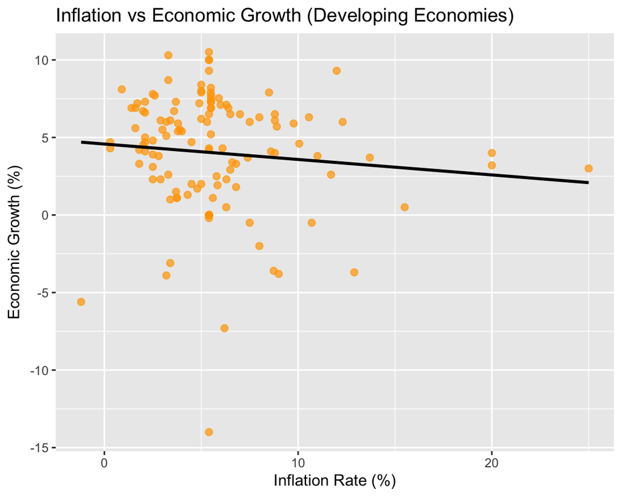

### Key Findings

#### How does inflation impact economic growth across different regions over time?

The relationship between inflation and economic growth varies by region, and is generally weak but directionally distinct.

Across all countries, there is a very weak positive relationship between inflation and growth, but with high variability and many outliers, suggesting that inflation alone does not strongly predict growth outcomes globally.

In developed economies, the relationship is more clearly positive — moderate inflation often accompanies stronger growth. These economies tend to experience lower inflation overall, and their growth rates are more stable. This supports the idea that moderate inflation may reflect or promote healthy economic activity in stable regions.

In developing economies, the trend reverses slightly. The relationship is weakly negative, meaning that as inflation increases, economic growth tends to decline slightly. This is likely due to greater vulnerability in developing economies to inflationary pressures, which can destabilize growth or reflect underlying structural challenges.

Overall, the impact of inflation on growth depends on the economic context. In more developed economies, inflation may be better managed and accompanied by productive investment. In contrast, high inflation in developing economies may reflect instability that disrupts growth.

#### Are there noticeable differences in inflation trends between developed and developing countries?

Yes — the inflation trends between developed and developing countries are noticeably different in both distribution and variability:

Developed economies show lower and more stable inflation rates, with most values tightly clustered between 0–5%. The distribution is relatively normal with few outliers. This reflects stronger monetary control and economic stability.

# Conclusion

### Conclusion

This project analyzed the distributions and relationships between inflation and economic growth across multiple countries over the past 16 years, with a focus on differences between developed and developing economies. The analysis found that the overall connection between inflation and growth is relatively weak, but is slightly stronger for countries with a more developed economy. These economies saw a positive relationship between inflation and growth, while economies that are still developing showed more volatile inflation and a slightly negative relationship with growth. Although we found these relationships, the strength of the relationships are still relatively weak, which points to the fact that economic growth is likely more attributable to external factors.

````r
---
title: "A Global Analysis on Inflation"
output:
  flexdashboard::flex_dashboard:
    theme:
      version: 4
      bootswatch: cyborg
      navar-bg: "purple"

    orientation: columns
    vertical_layout: fill
    source_code: embed
---

```{r, include=FALSE}
knitr::opts_chunk$set(echo = TRUE)
library(flexdashboard)
library(DT)
library(tidyverse)
library(plotly)
library(ggplot2)
data <- read.csv("~/Library/Containers/com.apple.mail/Data/Library/Mail Downloads/C684395E-F831-4E62-875C-95D09E960BFE/Economic Indicators And Inflation.csv")
data <- data %>%
  rename(
    GDP = `GDP..in.billion.USD.`,
    Inflation = `Inflation.Rate....`,
    Eco_Growth = `Economic.Growth....`
  )
data$Economic_Classification <- "Developing"
data$Economic_Classification[data$Country %in% c(
  "USA", "Canada", "Germany", "UK", "France", "Japan", "Australia", "Italy", "South Korea"
)] <- "Developed"
filtered_data <- data[!(data$Country %in% c("Turkey", "Indonesia")), ]

developed <- filtered_data[filtered_data$Economic_Classification == "Developed", ]
developing <- filtered_data[filtered_data$Economic_Classification == "Developing", ]


```

Introduction
===
Column {data-width=450}
---
### A Global Analysis on Inflation, By Scott Robbins
My project will explore a data set from Kaggle titled "Economic Indicators and Inflation" and will investigate the effects that inflation has on different countries. Inflation is defined as a general increase in prices and fall in the purchasing value of money. It is a crucial economic indicator that affects purchasing power, interest rates, and economic stability. I will analyze how inflation correlates with GDP and economic growth to investigate the following research questions: How does inflation impact economic growth across different
regions over time? Are there noticeable differences in inflation trends between developed and developing countries?

To explore my research question, I
will use summary statistics and distribution analysis of each data set. I will plot inflation
rates vs. economic growth and against GDP over time to see general trends across
different regions. I’ll be able to see positive or negative relationships between inflation
and economic growth, and compare trends among developed and
developing economies to see how different inflation rates affect each region.



```{r}

```

Column {.tabset data-width=550}
-----------------------------------------------------------------------

### Data Cleaning
- My first thought when I saw my data was that it had already been pre-processed and cleaned by the person who had collected the data, and therefore had no mistakes considering how easy it it to access world economic data.
- After closely reviewing the data I found many inconsistencies, particularly in Turkey and Indonesia's GDP and Inflation. Because of this, I chose not to include Turkey or Indonesia in conducting analysis that involved these variables.
- This dataset measures economic growth as the percent change in GDP. Therefore, with these inconsistencies in these country's GDP, I chose to ignore their data values altogether, creating a new variable called "filtered_data".





### Data Organization
- To organize my data, I created a new variable called "Economic Classification" which aimed to label each country in my data set as either a "Developed" or "Developing" Economy. This way I could identify the differences between how inflation impacts countries based on how advanced their economy is, rather than pooling every country into the same category.


Distributions of Inflation
===


Column{.tabset}
---
### Overall

#### Interpretation {data-width=400}
- For overall Inflation rates across all countries, the distribution was skewed to the right.
- The range was 26.2 percentage points, with an IQR of only 3.8 percentage points.
- There were 8 outliers, all positive, with the maximum value being 25% (Pakistan, 2024).

#### Charts
```{r, echo=FALSE, fig.width=8, fig.height=4}
p1<- ggplot(filtered_data, aes(x = Inflation)) +
  geom_histogram(binwidth = 1, fill = "blue", color = "black") +
  labs(
    title = "Histogram of Inflation Rates (All Countries)",
    x = "Inflation Rate (%)",
    y = "Frequency"
  )
p2<-ggplot(filtered_data, aes(y = Inflation)) +
  geom_boxplot(fill = "blue") +
  labs(title = "Overall Inflation Rate Distribution (All Countries)",
       y = "Inflation Rate (%)")
p3<-ggplot(developed, aes(x = Inflation)) +
  geom_histogram(binwidth = 1, fill = "orange", color = "black") +
  labs(
    title = "Histogram of Inflation Rates (Developed Economies)",
    x = "Inflation Rate (%)",
    y = "Frequency"
  )
p4<-ggplot(developing, aes(x = Inflation)) +
  geom_histogram(binwidth = 1, fill = "orange", color = "black") +
  labs(
    title = "Histogram of Inflation Rates (Developing Economies)",
    x = "Inflation Rate (%)",
    y = "Frequency"
  )
p5<-ggplot(filtered_data, aes(x = Economic_Classification, y = Inflation)) +
  geom_boxplot(fill = "orange") +
  labs(
    title = "Inflation Rate Distribution by Economic Classification",
    x = "Economic Classification",
    y = "Inflation Rate (%)")
print(p1)
```

```{r, echo=FALSE, fig.width=8, fig.height=4}
print(p2)
```

### Developed

#### Interpretation {data-width=400}
- Developed economies show a relatively normal distribution of inflation rates, with only 7 outliers.
- The minimum value was -0.72% and the Max was 8.7% (Italy, 2022), giving it a range of 9.42 percentage points.
- The IQR was 2 percentage points, and the median inflation rate was 1.81%.
- These statistics suggest that developing economies have had relatively stable and consistent rates of inflation over the past 16 years.

#### Charts
```{r, echo=FALSE}

print(p3)
```

```{r, echo=FALSE,  fig.width=8, fig.height=4}
print(p5)
```


### Developing

#### Interpretation {data-width=400}
- Inflation rates in developing economies saw much more volatile inflation rates over the years.
- The distribution is skewed to the right, with a minimum value of -1.2% and a maximum value of 25%, giving us a range of 26.2 percentage points.
- This range is far greater than the developed economies range of only 9.42 percent, showing much more instability and inconsistency.
````

````r
#### Charts
```{r, echo=FALSE}
print(p4)
```

```{r, echo=FALSE,  fig.width=8, fig.height=4}
print(p5)
```


Distributions of Economic Growth
===

Row{.tabset}
---
### Overall

#### Interpretation {data-width=400}
- For overall rates of economic growth across all countries in this data set, there is a relatively normal distribution despite the large amount of outliers on either side of the distribution.
- The range of the distribution is 24.5 percentage points and the IQR is only 3.2 percentage points.

#### Charts
```{r, echo=FALSE}

p6<-ggplot(filtered_data, aes(y = Eco_Growth)) +
  geom_boxplot(fill = "skyblue") +
  labs(title = "Overall Economic Growth Distribution (All Countries)",
       y = "Economic Growth (%)")
p7<-ggplot(filtered_data, aes(x = Eco_Growth)) +
  geom_histogram(binwidth = 0.5, fill = "skyblue", color = "black") +
  labs(
    title = "Histogram of Economic Growth (All Countries)",
    x = "Economic Growth (%)",
    y = "Frequency"
  )

p8<-ggplot(developed, aes(x = Eco_Growth)) +
  geom_histogram(binwidth = 0.5, fill = "lightgreen", color = "black") +
  labs(
    title = "Histogram of Economic Growth (Developed Economies)",
    x = "Economic Growth (%)",
    y = "Frequency"
  )

p9<-ggplot(developing, aes(x = Eco_Growth)) +
geom_histogram(binwidth = 0.5, fill = "lightgreen", color = "black") +
  labs(
    title = "Histogram of Economic Growth (Developing Economies)",
    x = "Economic Growth (%)",
    y = "Frequency"
  )
p10<-ggplot(filtered_data, aes(x = Economic_Classification, y = Eco_Growth)) +
  geom_boxplot(fill = "lightgreen") +
  labs(
    title = "Economic Growth Distribution by Economic Classification",
    x = "Economic Classification",
    y = "Economic Growth (%)"
  )
print(p7)
```

```{r, echo=FALSE, fig.width=8, fig.height=4}
print(p6)
```

### Developed

#### Interpretation
- For developed economies, the distribution of economic growth is approximately normal with a slight left tail due to the negative outliers.
- The bulk of the data is within 0-5% and the median is 2.2%.
- An IQR of 1.6 shows a rather low - yet stable - rate of economic growth across developed economies over time.

#### Charts
```{r, echo=FALSE}
print(p8)
```

```{r, echo=FALSE, fig.width=8, fig.height=4}
print(p10)

```

### Developing

#### Interpretation
- For developing economies, the distribution of economic growth is heavily skewed to the left with much more negative values.
- There is a range of 24.5 percentage points and an IQR of 4.86 percentage points.
- Despite the major volatility in inflation rates in developing economies, their median for economic growth is 4.65%, which is significantly higher than the median of growth for developed economies, 2.2%.


#### Charts
```{r, echo=FALSE}
print(p9)
```

```{r, echo=FALSE, fig.width=8, fig.height=4}
print(p10)
```


Scatterplot Analysis
===

Row{.tabset}
---
### Overall

#### Analysis
- After viewing the distributions of inflation rates and economic growth across different levels of economies, we can begin to investigate this projects 2 research questions:
  - How does inflation impact economic growth across different
regions over time?
  - Are there noticeable differences in inflation trends between developed and developing countries?
- The scatterplot of inflation rate and economic growth across all countries suggests a very weak positive linear relationship between inflation and economic growth across all countries. While the trendline slopes upward slightly, a wide dispersion of points indicates that inflation alone does not necessarily explain variation in growth.

#### Graph
```{r, echo=FALSE}
p11<- ggplot(filtered_data, aes(x = Inflation, y = Eco_Growth)) +
  geom_point(color = "blue", size = 2, alpha = 0.7) +
  geom_smooth(method = "lm", se = FALSE, color = "black") +
  labs(
    title = "Inflation vs Economic Growth (All Countries)",
    x = "Inflation Rate (%)",
    y = "Economic Growth (%)"
  )
p12<-ggplot(developed, aes(x = Inflation, y = Eco_Growth)) +
  geom_point(color = "lightgreen", size = 2, alpha = 0.7) +
  geom_smooth(method = "lm", se = FALSE, color = "black") +
  labs(
    title = "Inflation vs Economic Growth (Developed Economies)",
    x = "Inflation Rate (%)",
    y = "Economic Growth (%)"
  )
p13<-ggplot(developing, aes(x = Inflation, y = Eco_Growth)) +
  geom_point(color = "orange", size = 2, alpha = 0.7) +
  geom_smooth(method = "lm", se = FALSE, color = "black") +
  labs(
    title = "Inflation vs Economic Growth (Developing Economies)",
    x = "Inflation Rate (%)",
    y = "Economic Growth (%)"
  )

print(p11)
```

### Developed

#### Analysis
- In developed economies, the relationship between inflation and economic growth appears more consistent. The data shows a modest positive correlation, with countries experiencing moderate inflation often see stronger growth.
- While the relationship isn't perfectly linear, the lack of an extreme spread in both inflation and growth suggest that moderate inflation may support low, but stable, economic growth

#### Graph
```{r, echo=FALSE}
print(p12)
```

### Developing

#### Analysis
- For developing economies, the relationship between inflation and economic growth is slightly negative, meaning countries with higher inflation rates often see lower or unstable economic growth.
-  While many countries with moderate inflation still experience healthy growth, the data becomes more dispersed as inflation rises. This suggests that in developing economies, high inflation may contribute to economic instability, harming growth.
- However, the relationship between inflation and growth for developing economies is weak, meaning economic growth is likely to be less prone to influence by inflation alone compared to more developed economies.

#### Graph
```{r, echo=FALSE}
print(p13)
```

### Key Findings

####  How does inflation impact economic growth across different regions over time?
The relationship between inflation and economic growth varies by region, and is generally weak but directionally distinct.
````

```r
Across all countries, there is a very weak positive relationship between inflation and growth, but with high variability and many outliers, suggesting that inflation alone does not strongly predict growth outcomes globally.

In developed economies, the relationship is more clearly positive — moderate inflation often accompanies stronger growth. These economies tend to experience lower inflation overall, and their growth rates are more stable. This supports the idea that moderate inflation may reflect or promote healthy economic activity in stable regions.

In developing economies, the trend reverses slightly. The relationship is weakly negative, meaning that as inflation increases, economic growth tends to decline slightly. This is likely due to greater vulnerability in developing economies to inflationary pressures, which can destabilize growth or reflect underlying structural challenges.

Overall, the impact of inflation on growth depends on the economic context. In more developed economies, inflation may be better managed and accompanied by productive investment. In contrast, high inflation in developing economies may reflect instability that disrupts growth.

#### Are there noticeable differences in inflation trends between developed and developing countries?

Yes — the inflation trends between developed and developing countries are noticeably different in both distribution and variability:

Developed economies show lower and more stable inflation rates, with most values tightly clustered between 0–5%. The distribution is relatively normal with few outliers. This reflects stronger monetary control and economic stability.

Developing economies, on the other hand, exhibit wider and more skewed distributions. Inflation rates are often higher, and outliers — both high and low — are more common, showing greater volatility.



Conclusion
===
### Conclusion
This project analyzed the distributions and relationships between inflation and economic growth across multiple countries over the past 16 years, with a focus on differences between developed and developing economies. The analysis found that the overall connection between inflation and growth is relatively weak, but is slightly stronger for countries with a more developed economy. These economies saw a positive relationship between inflation and growth, while economies that are still developing showed more volatile inflation and a slightly negative relationship with growth. Although we found these relationships, the strength of the relationships are still relatively weak, which points to the fact that economic growth is likely more attributable to external factors.

### Limitations
While this analysis provides meaningful insights, it is important to recognize several limitations. First, the dataset used included a small number of years and countries, which may limit the generalizability of the findings. Furthermore, in finding drivers of economic growth, it would have been more useful to have access to other variables beyond inflation that an economy possesses which could be more attributable to economic growth.
### About Me
I am a Junior here at The University of Dayton pursuing a Bachelor of Arts in Economics with a minor in Data Analytics, and will graduate in May of 2026. Over the past three years I have worked in Guest and Member Services at Prestwick Country Club in my hometown of Frankfort, Illinois. However, after moving towards Chicago, I am actively seeking an internship to build upon my economic and statistical knowledge in the Chicago area.
```